# Capstone Project

Carlo Lopez Hernandez (07/07/2025)

**Project Overview**

This Jupyter Notebook contains all data cleaning steps, visualizations, and analysis conducted for the Capstone project: *"Technology Trends & Developer Demographics."*

The project explores:

- Current and emerging technologies
- Programming language usage
- Database preferences
- Developer demographics using global survey data

All insights were developed using **IBM Cognos dashboards** and are supported by exploratory data analysis in this notebook.

- Installing all necessary packages

```python
import pandas as pd
from collections import Counter
import seaborn as sns
import matplotlib.pyplot as plt
```

- Downloading Dataset (The dataset was provided by IBM)

```python
df = pd.read_csv("/Users/carlolopez/Desktop/IBM Certification/survey_data_updated 5.csv")
df.head(5)
```

|  | ResponseId | MainBranch | Age | Employment | RemoteWork | Check | CodingActivities | EdLevel | LearnCode | LearnCodeOnline | ... | JobSatPoints_6 | JobSatPoints_7 | JobSatPoints_8 | JobSatPoints_9 | JobSatPoints_10 | JobSatPoints_11 | SurveyLength | SurveyEase | ConvertedCompYearly | JobSat |
| --- | --- | --- | --- | --- | --- | --- | --- | --- | --- | --- | --- | --- | --- | --- | --- | --- | --- | --- | --- | --- | --- |
| 0 | 2 | I am a developer by profession | 35-44 years old | Employed, full-time | Remote | Apples | Hobby;Contribute to open-source projects;Other... | Bachelor's degree (B.A., B.S., B.Eng., etc.) | Books / Physical media;Colleague;On the job tr... | Technical documentation;Blogs;Books;Written Tu... | ... | 0.0 | 0.0 | 0.0 | 0.0 | 0.0 | 0.0 | NaN | NaN | NaN | NaN |
| 1 | 3 | I am a developer by profession | 45-54 years old | Employed, full-time | Remote | Apples | Hobby;Contribute to open-source projects;Other... | Master's degree (M.A., M.S., M.Eng., MBA, etc.) | Books / Physical media;Colleague;On the job tr... | Technical documentation;Blogs;Books;Written Tu... | ... | NaN | NaN | NaN | NaN | NaN | NaN | Appropriate in length | Easy | NaN | NaN |
| 2 | 10 | I am a developer by profession | 35-44 years old | Independent contractor, freelancer, or self-em... | Remote | Apples | Bootstrapping a business | Master's degree (M.A., M.S., M.Eng., MBA, etc.) | On the job training;Other online resources (e.... | Technical documentation;Blogs;Written Tutorial... | ... | NaN | NaN | NaN | NaN | NaN | NaN | Too long | Easy | NaN | NaN |
| 3 | 11 | I used to be a developer by profession, but no... | 35-44 years old | Employed, full-time | Remote | Apples | Hobby;Contribute to open-source projects | Bachelor's degree (B.A., B.S., B.Eng., etc.) | Books / Physical media;Other online resources ... | Technical documentation;Books;Written Tutorial... | ... | 25.0 | 10.0 | 0.0 | 15.0 | 0.0 | 0.0 | Appropriate in length | Easy | NaN | 8.0 |
| 4 | 12 | I am a developer by profession | 45-54 years old | Employed, full-time | In-person | Apples | Hobby;School or academic work | Professional degree (JD, MD, Ph.D, Ed.D, etc.) | Books / Physical media;School (i.e., Universit... | NaN | ... | NaN | NaN | NaN | NaN | NaN | NaN | Appropriate in length | Neither easy nor difficult | NaN | NaN |

5 rows × 114 columns

# Part 1: Current Technology Trends

this part will analyze what languages, databases, platforms, and webframes programmers **currently** work with

1. **Top 10 Languages Programmers **currently** work with**

```python
df["LanguageHaveWorkedWith"].head()
```

```
0    Bash/Shell (all shells);Go;HTML/CSS;Java;JavaS...
1                                                   C#
2                       HTML/CSS;JavaScript;TypeScript
3                               JavaScript;Python;Ruby
4    C;C#;C++;Delphi;HTML/CSS;Java;JavaScript;Power...
Name: LanguageHaveWorkedWith, dtype: object
```

- **Note:** Several columns in the dataset contain multiple programming languages or technologies in a single cell, separated by a semicolon (;). To prepare the data for analysis, these columns must first be split into individual entries, cleaned, and then counted. This will be done using Python's **Counter** class from the **collections** module.

```python
# from collections import Counter (already installed but included here for reference)

# Replace NaNs with empty strings for easier processing
df['LanguageHaveWorkedWith'] = df['LanguageHaveWorkedWith'].fillna('')

# Split on ';' and flatten
all_dbs = df['LanguageHaveWorkedWith'].str.split(';').sum()

# Remove empty strings and strip spaces
all_dbs = [db.strip() for db in all_dbs if db.strip()]

db_counts = Counter(all_dbs)

# Convert to DataFrame
db_counts_df = pd.DataFrame(db_counts.items(), columns=['Language', 'Count'])

# Sort for easier visualization
db_counts_df = db_counts_df.sort_values(by='Count', ascending=False)

# Save for import into Cognos (uncomment to save)
# db_counts_df.to_csv("Languages_df.csv", index=False)
```

**Top 10 Languages Worked With: Final Cleaned Table**

```python
db_counts_df.head(10)
```

|  | Language | Count |
| --- | --- | --- |
| 4 | JavaScript | 14943 |
| 13 | SQL | 12602 |
| 2 | HTML/CSS | 12410 |
| 6 | TypeScript | 10709 |
| 5 | Python | 9590 |
| 0 | Bash/Shell (all shells) | 7244 |
| 7 | C# | 6340 |
| 3 | Java | 5982 |
| 16 | PHP | 4644 |
| 12 | PowerShell | 3438 |

2. **Top 10 Databases Programmers **currently** work with**

```python
df["DatabaseHaveWorkedWith"].head()
```

```
0                          Dynamodb;MongoDB;PostgreSQL
1                           Firebase Realtime Database
2                       MongoDB;MySQL;PostgreSQL;Redis
3              Elasticsearch;MongoDB;PostgreSQL;SQLite
4    Microsoft Access;Microsoft SQL Server;PostgreS...
Name: DatabaseHaveWorkedWith, dtype: object
```

- **Note:** Similar to the previous column, this must be split counted, to reduce reducancy, assume we will do this with every column

```python
# Replace NaNs with empty strings for easier processing
df['DatabaseHaveWorkedWith'] = df['DatabaseHaveWorkedWith'].fillna('')

# Split on ';' and flatten
all_dbs2 = df['DatabaseHaveWorkedWith'].str.split(';').sum()

# Remove empty strings and strip spaces
all_dbs2 = [db.strip() for db in all_dbs2 if db.strip()]

db_counts2 = Counter(all_dbs2)

# Convert to DataFrame
db_counts_df2 = pd.DataFrame(db_counts2.items(), columns=['Database', 'Count'])

# Sort for easier visualization
db_counts_df2 = db_counts_df2.sort_values(by='Count', ascending=False)

# db_counts_df2.to_csv("Databases_df.csv", index=False)
```

**Top 10 Databases worked with: Final Cleaned Table**

```python
db_counts_df2.head(10)
```

|  | Database | Count |
| --- | --- | --- |
| 2 | PostgreSQL | 11514 |
| 4 | MySQL | 8556 |
| 7 | SQLite | 7021 |
| 1 | MongoDB | 5930 |
| 9 | Microsoft SQL Server | 5870 |
| 5 | Redis | 5814 |
| 11 | MariaDB | 3994 |
| 6 | Elasticsearch | 3491 |
| 0 | Dynamodb | 2268 |
| 20 | Oracle | 1907 |

3. **Top 10 Platforms programers *currently* work with**

```python
df["PlatformHaveWorkedWith"].head()
```

```
0             Amazon Web Services (AWS);Heroku;Netlify
1                                         Google Cloud
2    Amazon Web Services (AWS);Digital Ocean;Fireba...
3               Amazon Web Services (AWS);Google Cloud
4                                           Cloudflare
Name: PlatformHaveWorkedWith, dtype: object
```

```python
# Replace NaNs with empty strings for easier processing
df['PlatformHaveWorkedWith'] = df['PlatformHaveWorkedWith'].fillna('')

# Split on ';' and flatten
all_dbs3 = df['PlatformHaveWorkedWith'].str.split(';').sum()

# Remove empty strings and strip spaces
all_dbs3 = [db.strip() for db in all_dbs3 if db.strip()]

db_counts3 = Counter(all_dbs3)

# Convert to DataFrame
db_counts_df3 = pd.DataFrame(db_counts3.items(), columns=['Platform', 'Count'])

# Sort for easier visualization
db_counts_df3 = db_counts_df3.sort_values(by='Count', ascending=False)

#db_counts_df3.to_csv("Platforms_df.csv", index=False)
```

**Top 10 Platfrom Currently Worked With: Final Cleaned Table**

```python
db_counts_df3.head(10)
```

|  | Platform | Count |
| --- | --- | --- |
| 0 | Amazon Web Services (AWS) | 10871 |
| 8 | Microsoft Azure | 6681 |
| 3 | Google Cloud | 5537 |
| 7 | Cloudflare | 3874 |
| 4 | Digital Ocean | 3170 |
| 5 | Firebase | 3025 |
| 6 | Vercel | 2875 |
| 1 | Heroku | 2002 |
| 2 | Netlify | 1662 |
| 9 | Hetzner | 1392 |

4. **Top 10 Webframes programmers *currently* work with**

```python
df["WebframeHaveWorkedWith"].head()
```

```
0                        Express;Next.js;Node.js;React
1                                         ASP.NET CORE
2                        Express;Next.js;Node.js;React
3                          Node.js;React;Ruby on Rails
4    ASP.NET;ASP.NET CORE;Express;jQuery;Node.js;React
Name: WebframeHaveWorkedWith, dtype: object
```

```python
# Replace NaNs with empty strings for easier processing
df['WebframeHaveWorkedWith'] = df['WebframeHaveWorkedWith'].fillna('')

# Split on ';' and flatten
all_dbs4 = df['WebframeHaveWorkedWith'].str.split(';').sum()

# Remove empty strings and strip spaces
all_dbs4 = [db.strip() for db in all_dbs4 if db.strip()]

db_counts4 = Counter(all_dbs4)

# Convert to DataFrame
db_counts_df4 = pd.DataFrame(db_counts4.items(), columns=['Webframe', 'Count'])

# Sort for easier visualization
db_counts_df4 = db_counts_df4.sort_values(by='Count', ascending=False)

#db_counts_df4.to_csv("WebFrame_df.csv", index=False)
```

**Top 10 Webframe worked with: Final Cleaned Table**

```python
db_counts_df4.head(10)
```

|  | Webframe | Count |
| --- | --- | --- |
| 2 | Node.js | 9230 |
| 3 | React | 8999 |
| 7 | jQuery | 4810 |
| 0 | Express | 4408 |
| 1 | Next.js | 4399 |
| 4 | ASP.NET CORE | 4319 |
| 16 | Angular | 4038 |
| 15 | Vue.js | 3642 |
| 6 | ASP.NET | 3094 |
| 14 | Spring Boot | 2916 |

# Part 2: Future Technology Trends

this part will analyze what languages, databases, platforms, and webframes programmers **want** to work with

1. **Top 10 Languages Programmers **want** to work with**

```python
df["LanguageWantToWorkWith"].head()
```

```
0    Bash/Shell (all shells);Go;HTML/CSS;Java;JavaS...
1                                                   C#
2                       HTML/CSS;JavaScript;TypeScript
3               C#;Crystal;Java;JavaScript;Python;Ruby
4    C#;HTML/CSS;JavaScript;PowerShell;Rust;SQL;Typ...
Name: LanguageWantToWorkWith, dtype: object
```

```python
# Replace NaNs with empty strings for easier processing
df['LanguageWantToWorkWith'] = df['LanguageWantToWorkWith'].fillna('')

# Split on ';' and flatten
all_dbs5 = df['LanguageWantToWorkWith'].str.split(';').sum()

# Remove empty strings and strip spaces
all_dbs5 = [db.strip() for db in all_dbs5 if db.strip()]

db_counts5 = Counter(all_dbs5)

# Convert to DataFrame
db_counts_df5 = pd.DataFrame(db_counts5.items(), columns=['Language', 'Count'])

# Sort for easier visualization
db_counts_df5 = db_counts_df5.sort_values(by='Count', ascending=False)

# db_counts_df5.to_csv("Languages2_df.csv", index=False)
```

[output not shown]

**Top 10 languages want to worked with: Final Cleaned Table**

```python
db_counts_df5.head(10)
```

|  | Language | Count |
| --- | --- | --- |
| 4 | JavaScript | 11541 |
| 13 | SQL | 10944 |
| 7 | TypeScript | 10437 |
| 2 | HTML/CSS | 10016 |
| 6 | Python | 8919 |
| 1 | Go | 5661 |
| 12 | Rust | 5597 |
| 8 | C# | 5590 |
| 0 | Bash/Shell (all shells) | 5582 |
| 3 | Java | 4048 |

2. **Top 10 Databases Programmers **want** to work with**

```python
df["DatabaseWantToWorkWith"].head()
```

```
0                                 PostgreSQL
1                 Firebase Realtime Database
2             MongoDB;MySQL;PostgreSQL;Redis
3    Elasticsearch;MongoDB;PostgreSQL;SQLite
4     Microsoft SQL Server;PostgreSQL;SQLite
Name: DatabaseWantToWorkWith, dtype: object
```

```python
# Replace NaNs with empty strings for easier processing
df['DatabaseWantToWorkWith'] = df['DatabaseWantToWorkWith'].fillna('')

# Split on ';' and flatten
all_dbs6 = df['DatabaseWantToWorkWith'].str.split(';').sum()

# Remove empty strings and strip spaces
all_dbs6 = [db.strip() for db in all_dbs6 if db.strip()]

db_counts6 = Counter(all_dbs6)

# Convert to DataFrame
db_counts_df6 = pd.DataFrame(db_counts6.items(), columns=['Database', 'Count'])

# Sort for easier visualization
db_counts_df6 = db_counts_df6.sort_values(by='Count', ascending=False)

# db_counts_df6.to_csv("Databases2_df.csv", index=False)
```

**Top 10 Databases want to worked with: Final Cleaned Table**

```python
db_counts_df6.head(10)
```

|  | Database | Count |
| --- | --- | --- |
| 0 | PostgreSQL | 12193 |
| 4 | Redis | 6384 |
| 6 | SQLite | 6295 |
| 3 | MySQL | 6204 |
| 2 | MongoDB | 5618 |
| 7 | Microsoft SQL Server | 4345 |
| 5 | Elasticsearch | 3665 |
| 9 | MariaDB | 3078 |
| 11 | Dynamodb | 2154 |
| 23 | Supabase | 1623 |

3. **Top 10 Platforms Programmers **want** to work with**

```python
df["PlatformWantToWorkWith"].head()
```

```
0             Amazon Web Services (AWS);Heroku;Netlify
1                                         Google Cloud
2    Amazon Web Services (AWS);Digital Ocean;Fireba...
3                                         Google Cloud
4                                           Cloudflare
Name: PlatformWantToWorkWith, dtype: object
```

```python
# Replace NaNs with empty strings for easier processing
df['PlatformWantToWorkWith'] = df['PlatformWantToWorkWith'].fillna('')

# Split on ';' and flatten
all_dbs7 = df['PlatformWantToWorkWith'].str.split(';').sum()

# Remove empty strings and strip spaces
all_dbs7 = [db.strip() for db in all_dbs7 if db.strip()]

db_counts7 = Counter(all_dbs7)

# Convert to DataFrame
db_counts_df7 = pd.DataFrame(db_counts7.items(), columns=['Platform', 'Count'])

# Sort for easier visualization
db_counts_df7 = db_counts_df7.sort_values(by='Count', ascending=False)

# db_counts_df7.to_csv("Platfrom2_df.csv", index=False)
```

**Top 10 Platforms want to worked with: Final Cleaned Table**

```python
db_counts_df7.head(10)
```

|  | Platform | Count |
| --- | --- | --- |
| 0 | Amazon Web Services (AWS) | 10516 |
| 8 | Microsoft Azure | 6380 |
| 3 | Google Cloud | 5431 |
| 7 | Cloudflare | 4219 |
| 4 | Digital Ocean | 2908 |
| 6 | Vercel | 2776 |
| 5 | Firebase | 2720 |
| 10 | Hetzner | 1577 |
| 15 | Supabase | 1368 |
| 2 | Netlify | 1267 |

4. **Top 10 Webframes Programmers **want** to work with**

```python
df["WebframeWantToWorkWith"].head()
```

```
0                     Express;Htmx;Node.js;React;Remix
1                                         ASP.NET CORE
2                        Express;Next.js;Node.js;React
3                   Django;Node.js;React;Ruby on Rails
4    ASP.NET;ASP.NET CORE;Express;jQuery;Node.js;React
Name: WebframeWantToWorkWith, dtype: object
```

```python
# Replace NaNs with empty strings for easier processing
df['WebframeWantToWorkWith'] = df['WebframeWantToWorkWith'].fillna('')

# Split on ';' and flatten
all_dbs8 = df['WebframeWantToWorkWith'].str.split(';').sum()

# Remove empty strings and strip spaces
all_dbs8 = [db.strip() for db in all_dbs8 if db.strip()]

db_counts8 = Counter(all_dbs8)

# Convert to DataFrame
db_counts_df8 = pd.DataFrame(db_counts8.items(), columns=['WebFrame', 'Count'])

# Sort for easier visualization
db_counts_df8 = db_counts_df8.sort_values(by='Count', ascending=False)

#db_counts_df8.to_csv("WebFrame2_df.csv", index=False)
```

**Top 10 Webframes want to worked with: Final Cleaned Table**

```python
db_counts_df8.head(10)
```

|  | WebFrame | Count |
| --- | --- | --- |
| 3 | React | 8223 |
| 2 | Node.js | 8096 |
| 6 | Next.js | 4458 |
| 5 | ASP.NET CORE | 4166 |
| 15 | Vue.js | 3903 |
| 13 | Angular | 3309 |
| 0 | Express | 3216 |
| 19 | FastAPI | 2823 |
| 17 | Spring Boot | 2674 |
| 24 | Svelte | 2559 |

# Part 3: Extra Analysis

```python
df["Age"].unique()
```

```
array(['35-44 years old', '45-54 years old', '25-34 years old',
       '55-64 years old', '18-24 years old', 'Under 18 years old',
       '65 years or older', 'Prefer not to say'], dtype=object)
```

```python
df["AIToolCurrently Using"].head()
```

```
0                                                  NaN
1                                                  NaN
2                                   Search for answers
3    Learning about a codebase;Writing code;Documen...
4                                                  NaN
Name: AIToolCurrently Using, dtype: object
```

```python
# Drop rows with missing values in AIToolCurrently Using
df_clean = df.dropna(subset=["AIToolCurrently Using"])

# Split the semicolon-separated strings into lists
df_clean["AI_Use_List"] = df_clean["AIToolCurrently Using"].str.split(";")

# Explode so each use case is its own row
df_exploded = df_clean.explode("AI_Use_List")

# Remove extra spaces
df_exploded["AI_Use_List"] = df_exploded["AI_Use_List"].str.strip()

# Group by Age and Use Case, then count
summary = df_exploded.groupby(["Age", "AI_Use_List"]).size().reset_index(name="Count")

# Pivot to get a table with use cases as columns
pivot_table = summary.pivot(index="Age", columns="AI_Use_List", values="Count").fillna(0).astype(int)

# Optional: sort age groups in logical order (custom sort)
age_order = ["18-24 years old", "25-34 years old", "35-44 years old", "45-54 years old", "55-64 years old", "65 years or older"]
pivot_table = pivot_table.reindex(age_order).dropna(how="all")

# Show result
pivot_table

# pivot_table.to_csv("ai_use_by_age.csv")
```

| AI_Use_List Age | Committing and reviewing code | Debugging and getting help | Deployment and monitoring | Documenting code | Generating content or synthetic data | Learning about a codebase | Other (please specify): | Predictive analytics | Project planning | Search for answers | Testing code | Writing code |
| --- | --- | --- | --- | --- | --- | --- | --- | --- | --- | --- | --- | --- |
| 18-24 years old | 300 | 1470 | 127 | 1126 | 1020 | 706 | 12 | 147 | 413 | 1536 | 639 | 1917 |
| 25-34 years old | 733 | 3190 | 260 | 2442 | 2248 | 1605 | 34 | 293 | 689 | 3671 | 1804 | 4601 |
| 35-44 years old | 425 | 1730 | 142 | 1476 | 1219 | 1058 | 49 | 159 | 320 | 2205 | 1117 | 2877 |
| 45-54 years old | 166 | 607 | 44 | 518 | 388 | 428 | 25 | 62 | 91 | 856 | 387 | 1071 |
| 55-64 years old | 44 | 160 | 9 | 117 | 94 | 118 | 6 | 14 | 17 | 216 | 97 | 277 |
| 65 years or older | 5 | 17 | 2 | 12 | 7 | 12 | 0 | 2 | 1 | 23 | 10 | 34 |

**Creating a heatmap**

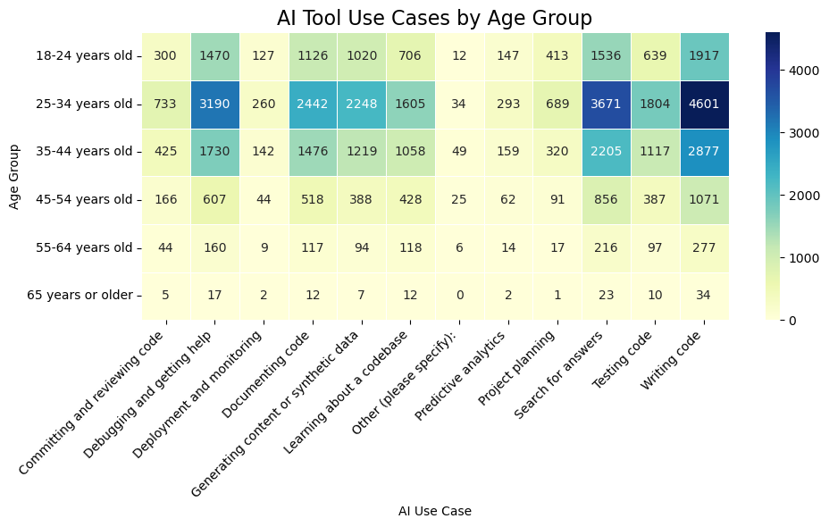

```python
# import seaborn as sns
# import matplotlib.pyplot as plt

plt.figure(figsize=(10, 6))
sns.heatmap(pivot_table, annot=True, fmt='d', cmap="YlGnBu", linewidths=0.5)
plt.title("AI Tool Use Cases by Age Group", fontsize=16)
plt.xlabel("AI Use Case")
plt.ylabel("Age Group")
plt.xticks(rotation=45, ha='right')
plt.tight_layout()
plt.show()
```

- **Age group usage, split by top 10 databases**

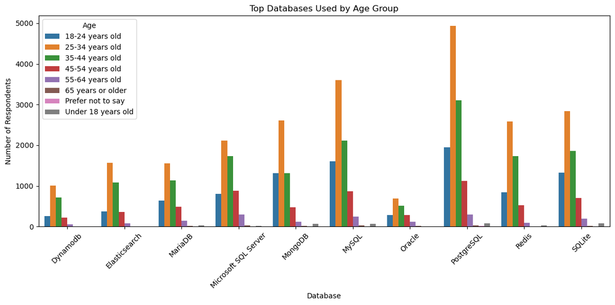

```python
# Drop rows where DatabaseHaveWorkedWith or Age is missing
df_cleaned = df.dropna(subset=["DatabaseHaveWorkedWith", "Age"])

# Split the semicolon-separated values into lists
df_cleaned["DatabaseList"] = df_cleaned["DatabaseHaveWorkedWith"].str.split(";")

# Explode the list into separate rows (long format)
df_exploded = df_cleaned.explode("DatabaseList")

# Optional: Clean up any whitespace
df_exploded["DatabaseList"] = df_exploded["DatabaseList"].str.strip()

# Count databases per age group
db_counts = df_exploded.groupby(["Age", "DatabaseList"]).size().reset_index(name="Count")

# Sort by most popular databases overall (optional, to keep plot clean)
top_dbs = db_counts.groupby("DatabaseList")["Count"].sum().nlargest(10).index
filtered = db_counts[db_counts["DatabaseList"].isin(top_dbs)]

plt.figure(figsize=(12, 6))
sns.barplot(data=filtered, x="DatabaseList", y="Count", hue="Age")
plt.title("Top Databases Used by Age Group")
plt.xlabel("Database")
plt.ylabel("Number of Respondents")
plt.xticks(rotation=45)
plt.legend(title="Age")
plt.tight_layout()
plt.show()
```

- **Median Compensationby Programming Language**

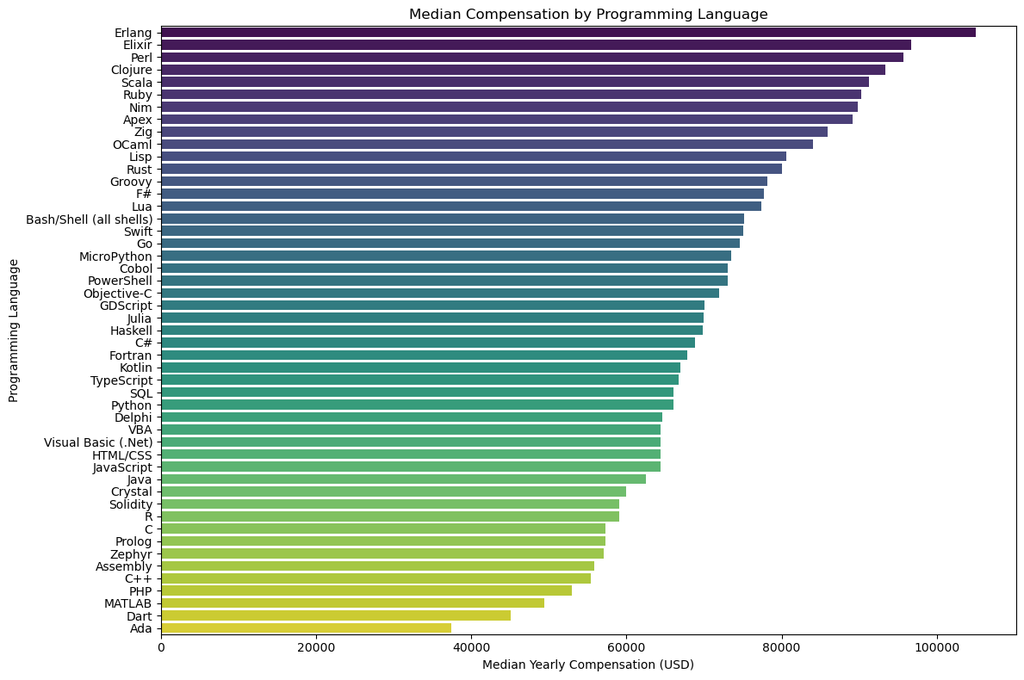

```python
# Step 1: Clean & preprocess
# Drop rows with NaN or zero compensation or empty language info
df_clean = df.dropna(subset=['ConvertedCompYearly', 'LanguageHaveWorkedWith'])
df_clean = df_clean[df_clean['ConvertedCompYearly'] > 0]

# Split and explode languages
df_clean['LanguageHaveWorkedWith'] = df_clean['LanguageHaveWorkedWith'].str.split(';')
df_exploded = df_clean.explode('LanguageHaveWorkedWith')

# Optional: strip whitespace
df_exploded['LanguageHaveWorkedWith'] = df_exploded['LanguageHaveWorkedWith'].str.strip()

# Step 2: Aggregate mean compensation by language
comp_by_lang = df_exploded.groupby('LanguageHaveWorkedWith')['ConvertedCompYearly'].median().sort_values(ascending=False)

# Step 3: Plot
plt.figure(figsize=(12,8))
sns.barplot(x=comp_by_lang.values, y=comp_by_lang.index, palette='viridis')
plt.xlabel('Median Yearly Compensation (USD)')
plt.ylabel('Programming Language')
plt.title('Median Compensation by Programming Language')
plt.tight_layout()
plt.show()
```

- **Top 10 programming languages by median compensation**

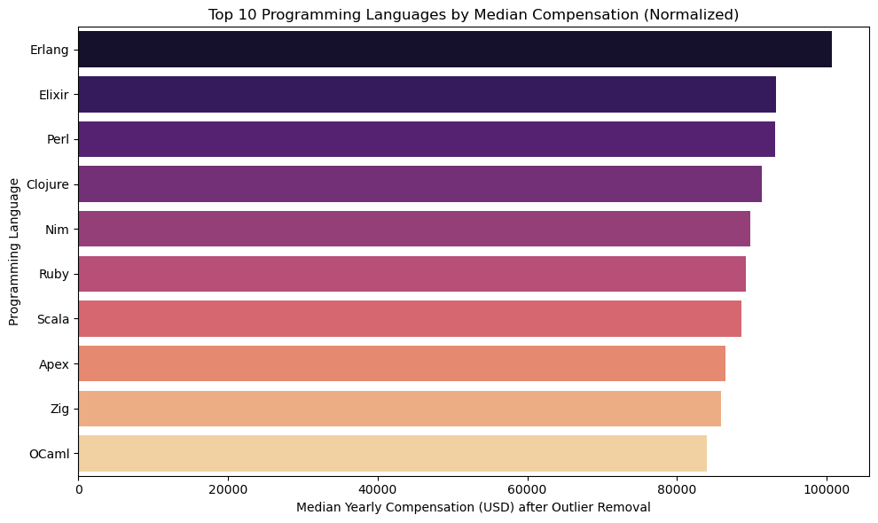

```python
def remove_outliers_iqr(series):
    Q1 = series.quantile(0.25)
    Q3 = series.quantile(0.75)
    IQR = Q3 - Q1
    lower_bound = Q1 - 1.5 * IQR
    upper_bound = Q3 + 1.5 * IQR
    return series[(series >= lower_bound) & (series <= upper_bound)]

# Prepare an empty dict to store median compensation after outlier removal
median_comp_cleaned = {}

for lang, group in df_exploded.groupby('LanguageHaveWorkedWith'):
    comp_no_outliers = remove_outliers_iqr(group['ConvertedCompYearly'])
    if len(comp_no_outliers) > 5:  # Only consider languages with >5 samples after cleaning
        median_comp_cleaned[lang] = comp_no_outliers.median()

# Convert to Series and get top 10
median_comp_cleaned = pd.Series(median_comp_cleaned).sort_values(ascending=False).head(10)

# Plot top 10
plt.figure(figsize=(10,6))
sns.barplot(x=median_comp_cleaned.values, y=median_comp_cleaned.index, palette='magma')
plt.xlabel('Median Yearly Compensation (USD) after Outlier Removal')
plt.ylabel('Programming Language')
plt.title('Top 10 Programming Languages by Median Compensation (Normalized)')
plt.tight_layout()
plt.show()
```

- **Top 10 programming languages by average compensation**

```
LanguageHaveWorkedWith
Elixir     135684.645078
Apex       131017.445652
Erlang     130413.568345
Ada        125847.151515
Cobol      124119.640000
Ruby       118514.638924
Clojure    117681.685714
Lisp       115758.196850
Scala      111853.306050
Haskell    108415.721805
Name: ConvertedCompYearly, dtype: float64
```

[figure not shown]

```python
# Calculate mean compensation by language (without outlier removal)
avg_comp_by_lang = df_exploded.groupby('LanguageHaveWorkedWith')['ConvertedCompYearly'].mean().sort_values(ascending=False)

# Display the top 10 highest paying languages by average compensation
print(avg_comp_by_lang.head(10))

# Step: Visualize top 10 programming languages by average compensation (after outlier removal)
top10_avg_comp = avg_comp_by_lang.sort_values(ascending=False).head(10)

plt.figure(figsize=(10, 6))
sns.barplot(x=top10_avg_comp.values, y=top10_avg_comp.index, palette='coolwarm')
plt.xlabel('Average Yearly Compensation (USD) after Outlier Removal')
plt.ylabel('Programming Language')
plt.title('Top 10 Programming Languages by Average Compensation (Normalized)')
plt.tight_layout()
plt.show()
```

- **Top 10 programming languages by average compensation (data labels added)**

[figure not shown]

```python
# Plot setup
top10_avg_comp = avg_comp_by_lang.sort_values(ascending=False).head(10)

plt.figure(figsize=(8, 6))
ax = sns.barplot(x=top10_avg_comp.values, y=top10_avg_comp.index, palette='coolwarm')

# Add value labels to the end of each bar
for i, value in enumerate(top10_avg_comp.values):
    ax.text(value + 1000, i, f"${value:,.0f}", va='center')  # adjust +1000 as padding if needed

plt.xlabel('Average Yearly Compensation (USD) after Outlier Removal')
plt.ylabel('Programming Language')
plt.title('Top 10 Programming Languages by Average Compensation (Normalized)')
plt.tight_layout()
plt.show()
```